# We are so back?

American democracy after the 2026 midterms

Noah Buckley

19 November 2026

## #1: nearly every county moved the same way

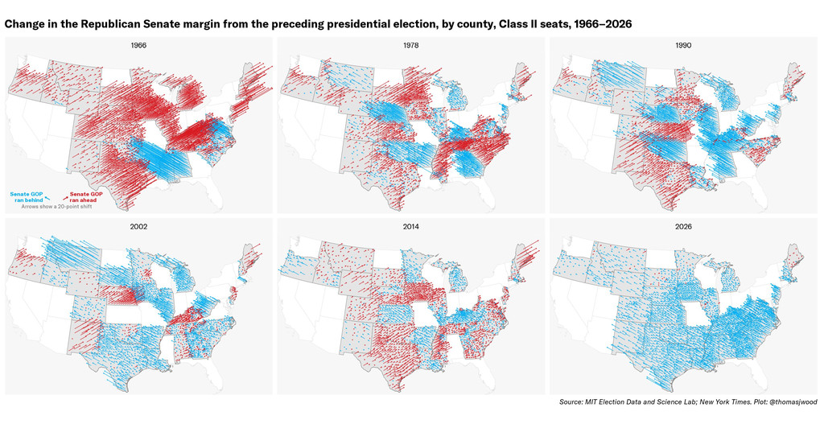

Thomas Wood (@thomasjwood); MIT Election Data and Science Lab, New York Times

## #2: Texas, minus Dallas, Austin and Houston

[figure not shown]

[figure not shown]

> Democracy is a system in which parties lose elections

> Adam Przeworski

> But it would be really nice if we could do better than that

> Noah Buckley

## My three main points tonight

1. **American democracy passed its test—so far**
   - Maybe not totally “healthy”, but it’s working where it counts: the president’s party can still lose
2. **Trump is not the main story; the thermostat is**
   - Voters punished the party in power the way they always do, only more so
3. **The danger is not just one person, it’s the party**
   - Many hard tests are still ahead

## An easy test has been passed. One hard one to go

1 · Test passed

- The president’s party has now lost House seats in **19 of 21** midterms since 1946
- So the result shows that **normal politics still works**. That matters, but it was the easy test
- **Hard test:** does the White House respect what a hostile Congress does with its power?

## Was it a “fully” free and fair election?

1 · Test passed

|  | What we’d look for | So far |
| --- | --- | --- |
| **Rules** | Late changes to maps, rolls or ID? | Gerrymanders on both sides; courts blocked the president’s election orders |
| **Observers** | Are outsiders allowed to watch? | **No.** The OSCE was not invited, a first |
| **Count** | Certification, litigation? | A DOJ suit over Alaska’s count |
| **After** | Did the president accept? | On the night, yes. Six days later: “Does anybody really believe that this ‘Election’ was honest” |

## V-Dem: the US against Hungary, Turkey, Russia

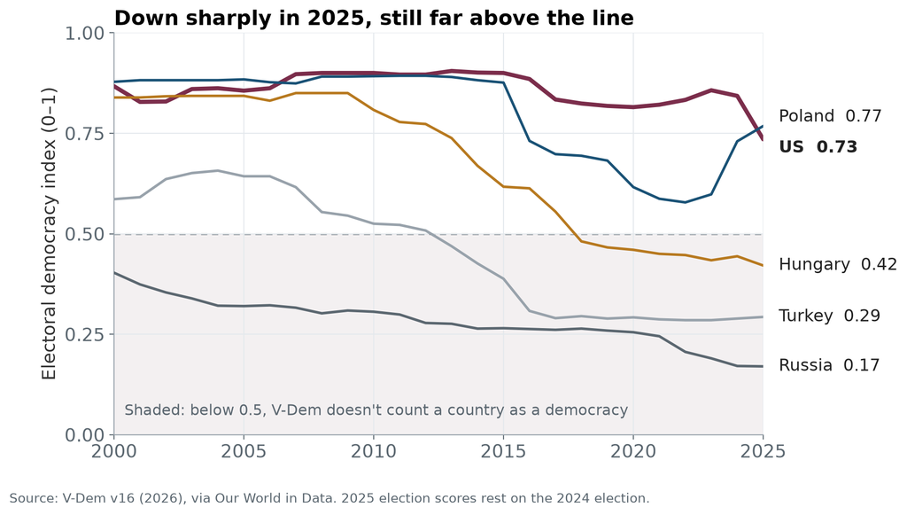

## Did the places hit hardest by gas prices swing hardest?

2 · The thermostat works

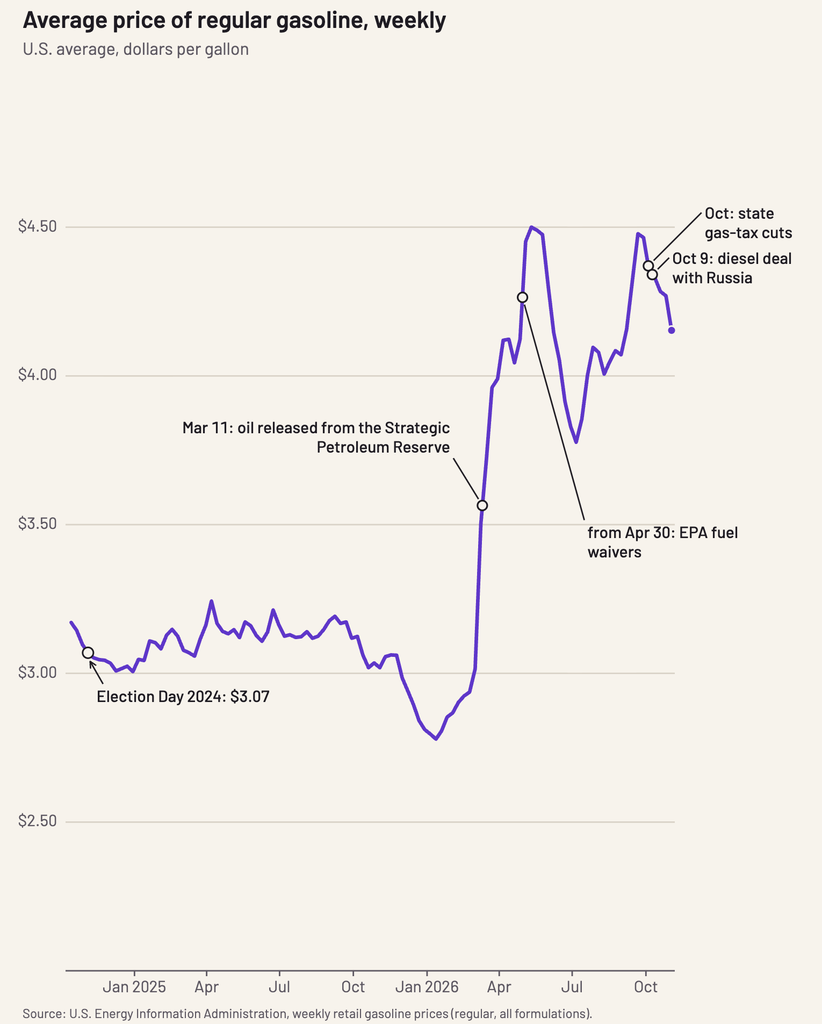

[figure not shown]

[figure not shown]

Check out: **chdausgaard.github.io/fuel-2026**, by Christoffer Dausgaard (Copenhagen). Chart: his, from EIA weekly prices

## What does a personalist president do with a hostile Congress?

3 · The party

- From January, Democrats hold **subpoenas, budgets and investigations**
- **Corruption** was high on priority list, so expect a lot of investigations
- What matters for democracy is the response: **comply, stonewall or escalate?**

## The Republican party moved *right*, not toward the voters

3 · The party

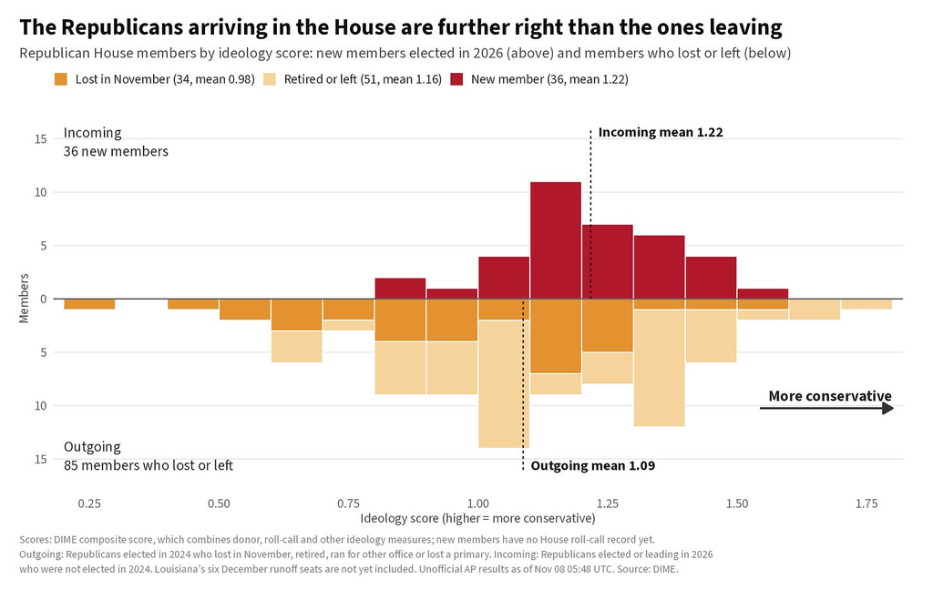

Adam Bonica, *On Data and Democracy*, Nov 2026; DIME scores, unofficial AP results 8 Nov

## MAGA/Trumpism *may* collapse but the GOP must not

3 · The party

- Federalism and presidentialism have their upsides, and they remain strong: the opposition now has power bases of its own
- The temperature is probably about to be turned up
- Personalist parties are bad at succession
- In a different context — authoritarian countries — succession is when these systems are most fragile and most dangerous
- Democracies need a healthy conservative party that practices **forbearance**

## What to watch now 👀

- The presidency is still a very strong institution – “imperial presidency”
- Compliance with House subpoenas and court orders
- Republicans acting independently: retirements, votes, primaries
- How the succession gets settled and how the GOP holds together

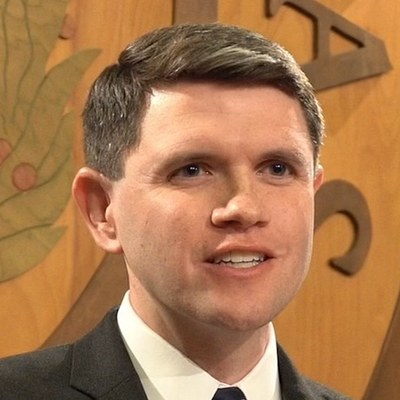

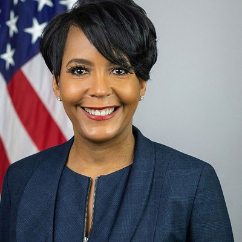

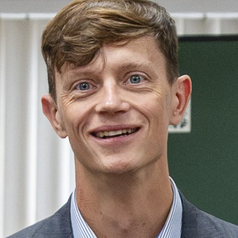

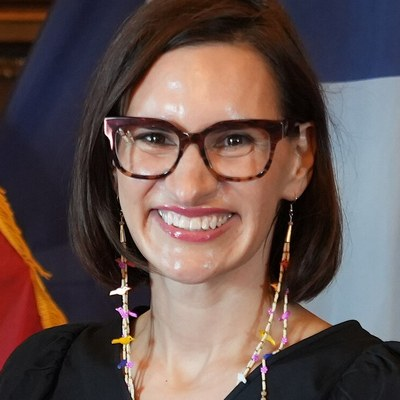

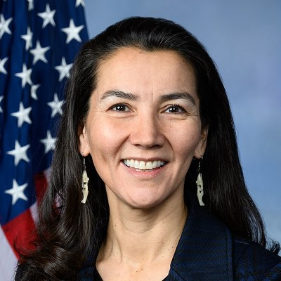

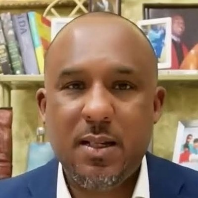

## Thank you

**Noah Buckley**

noah.buckley@tcd.ie

# Charts for Q&A

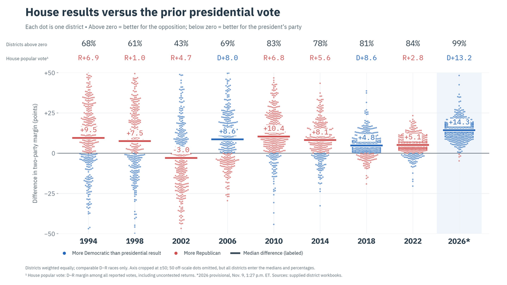

Thomas Wood (@thomasjwood), from district workbooks; 2026 provisional, 9 Nov

## The Senate map

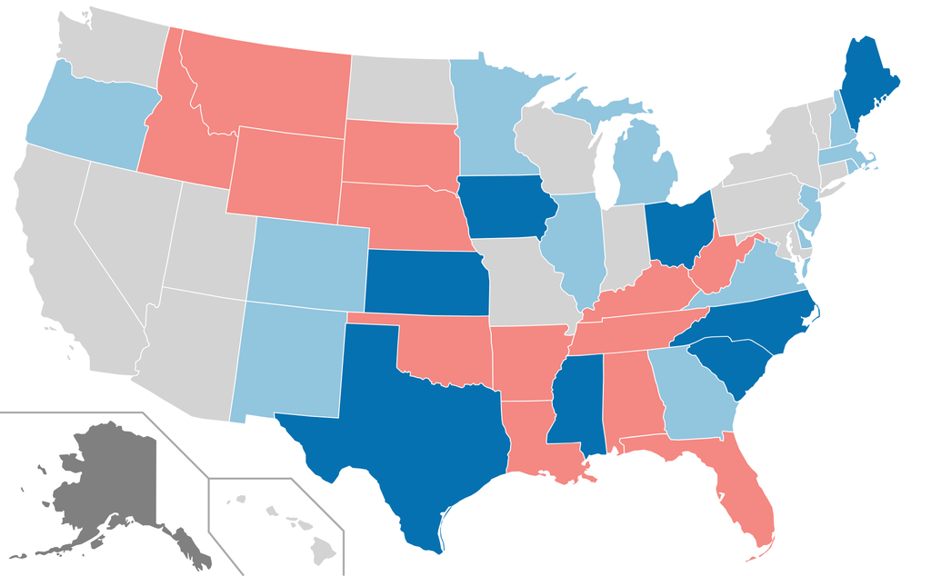

Wikimedia Commons, “2026 United States Senate elections results map”, CC BY 4.0, version of 11 Nov 2026

## Corruption topped the issue list

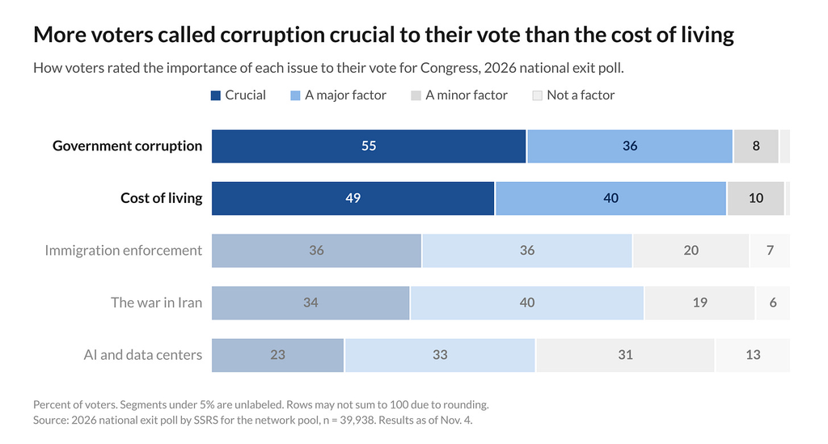

2026 national exit poll (SSRS for the network pool), n = 39,938; chart by Adam Bonica

## Who moved: the exit polls, 1998–2026

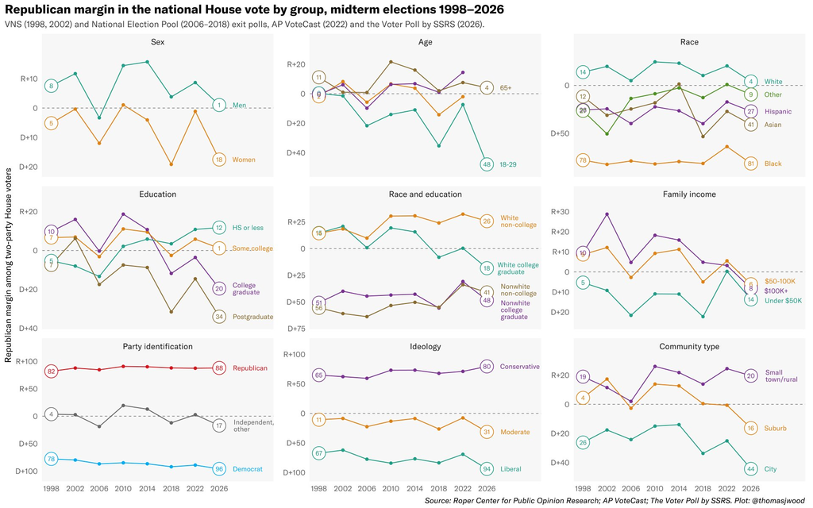

Thomas Wood (@thomasjwood); Roper Center, AP VoteCast, Voter Poll by SSRS

## Social issues sort by party, not demography

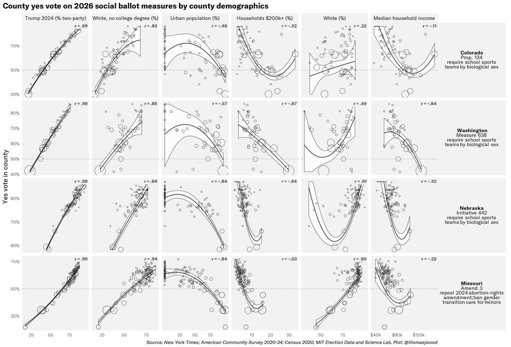

Thomas Wood (@thomasjwood); New York Times, ACS 2020–24, Census 2020, MEDSL

## Turnout: Democrats out-voted Republicans for once

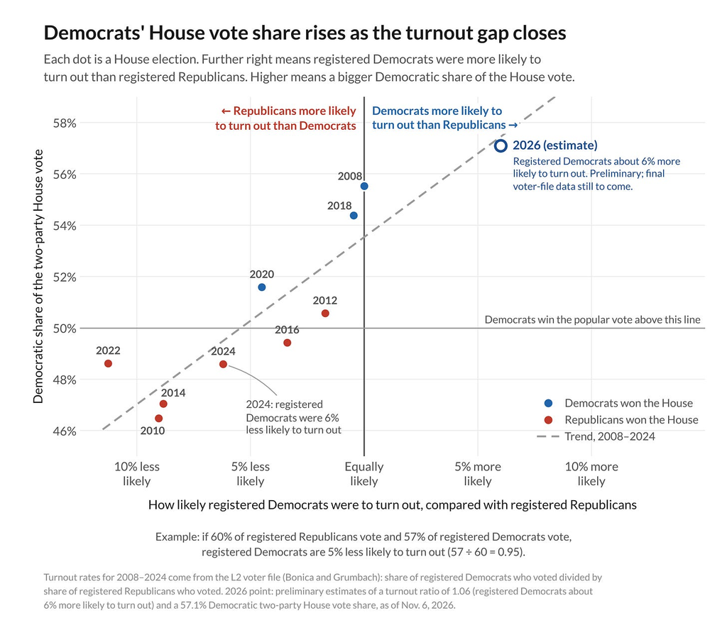

Adam Bonica; L2 voter file (Bonica & Grumbach) 2008–24; 2026 preliminary, 6 Nov

## House Democrats get much younger

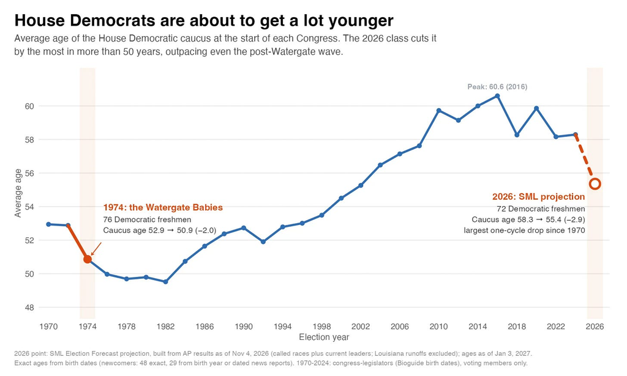

Adam Bonica; SML projection from AP results as of 4 Nov; Bioguide birth dates

## Where the swing was biggest

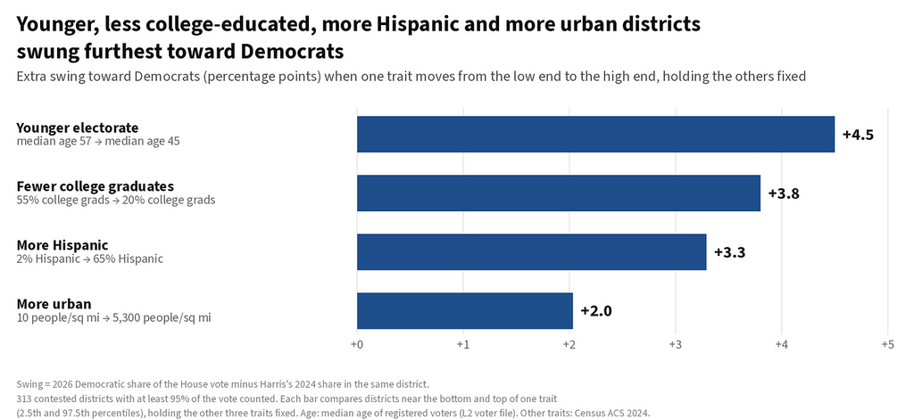

Adam Bonica; 313 contested districts ≥95% counted; L2, ACS 2024

## Progressive or centrist, the same gain

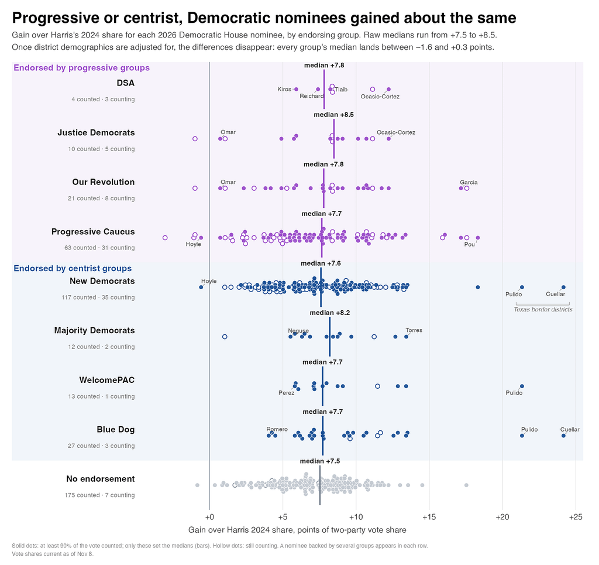

Adam Bonica; vote shares as of 8 Nov

## Parties are electable, not candidates (1/3)

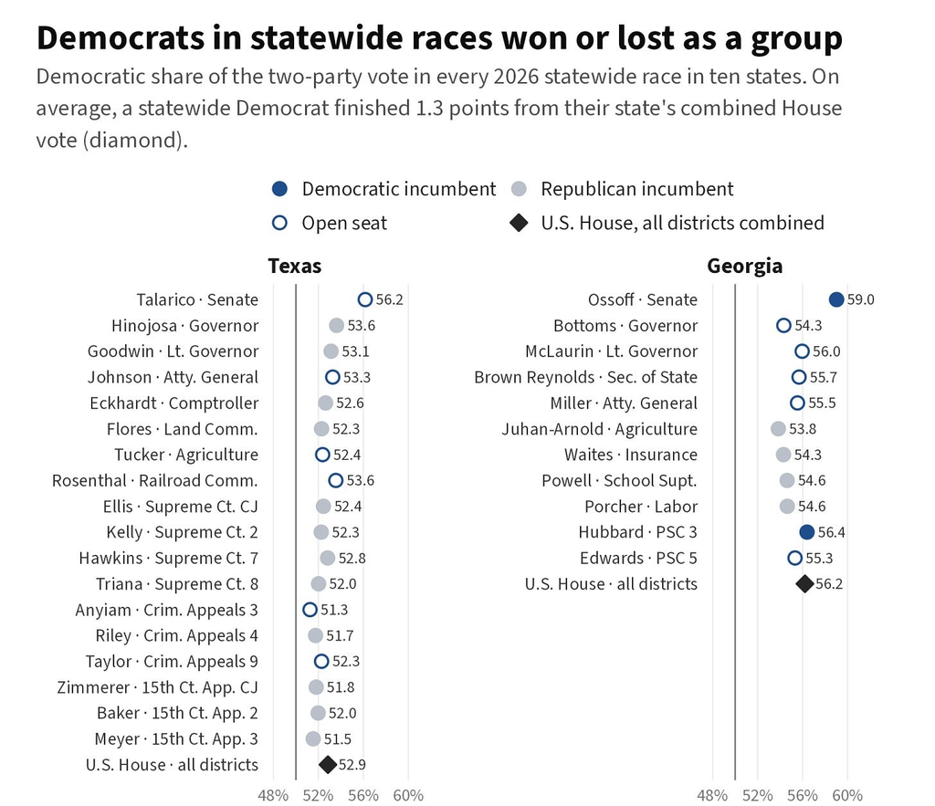

Adam Bonica; AP results as of 8 Nov

## Parties are electable, not candidates (2/3)

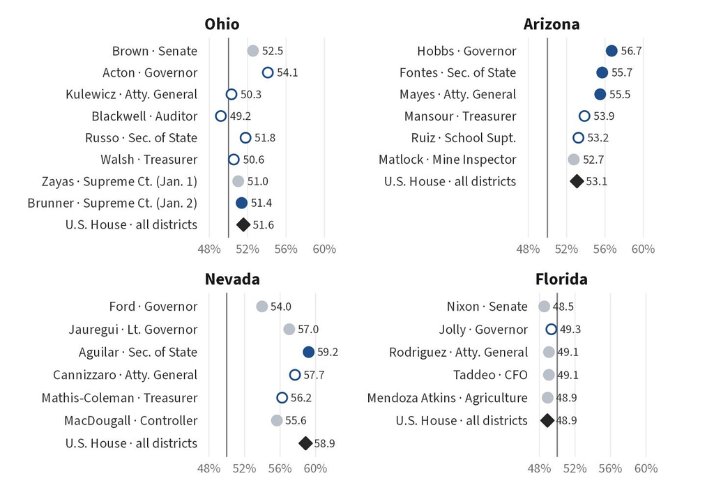

Adam Bonica; AP results as of 8 Nov

## Parties are electable, not candidates (3/3)

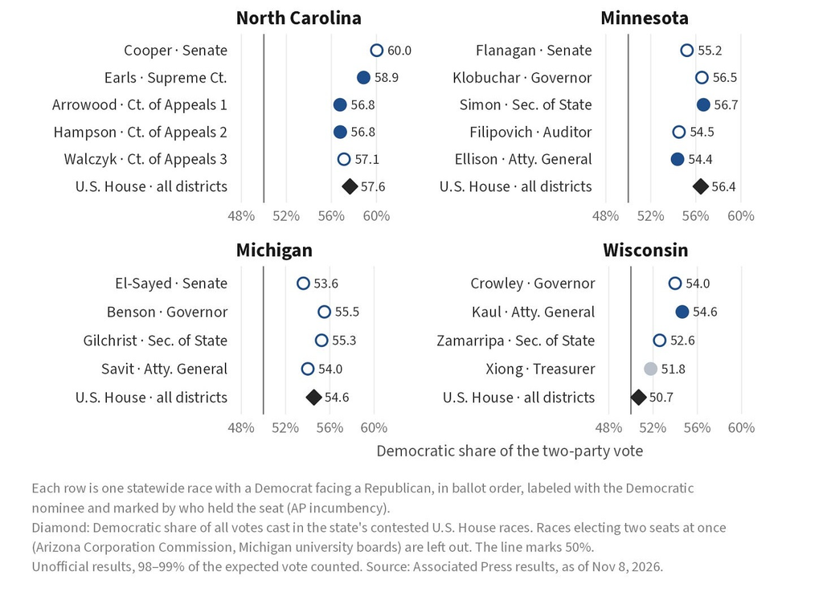

Adam Bonica; AP results as of 8 Nov

## Democrats arriving are slightly less liberal

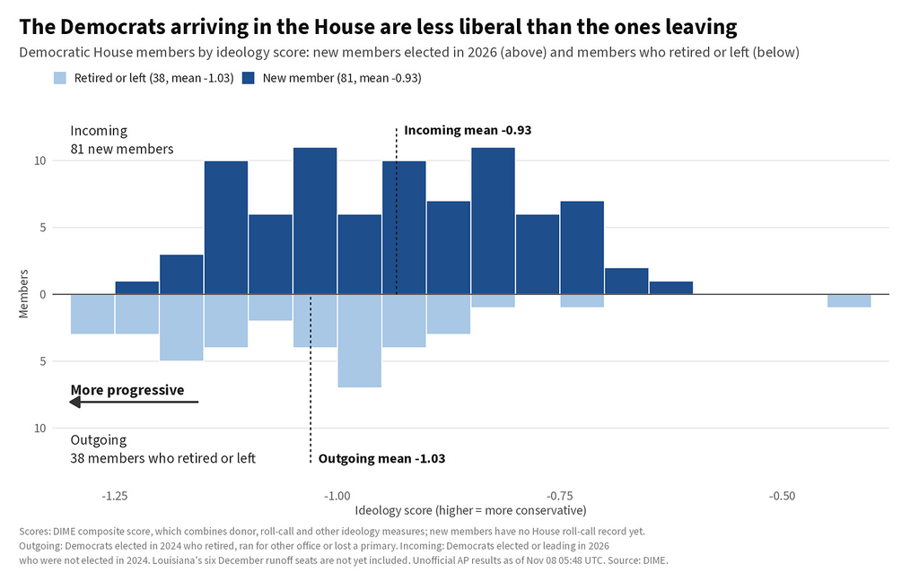

Adam Bonica; DIME scores, unofficial AP results 8 Nov

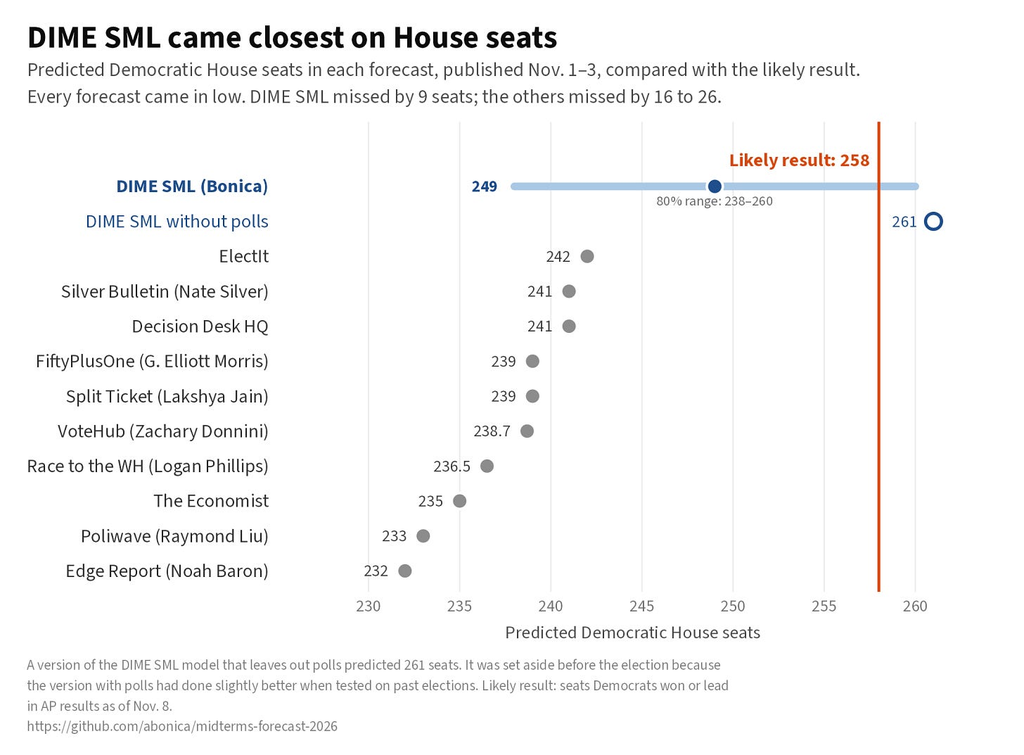

Adam Bonica; forecasts published 1–3 Nov; likely result per AP, 8 Nov

## Gas prices: the estimate and what it rules out

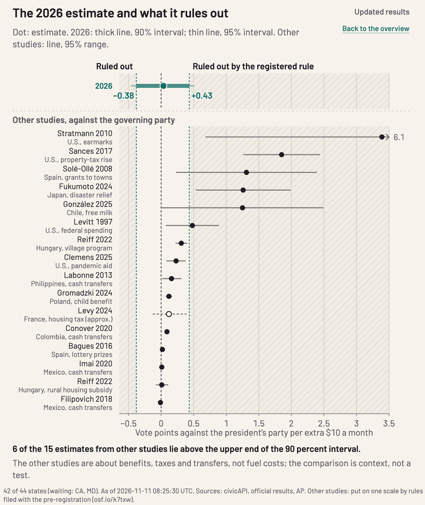

Christoffer Dausgaard, chdausgaard.github.io/fuel-2026, results as of 11 Nov (42 of 44 states); pre-registered at osf.io/k7txw